# Exploring the BRFSS data

Raymond Ngiam

28 May 2016

## Setup

### Load packages

```r
library(ggplot2)
library(dplyr)
```

### Load data

```r
load("brfss2013.RData")
```

## Part 1: Data

**How the observations in the sample are collected:**

BRFSS conducts both landline telephone- and cellular telephone-based surveys. Stratified sampling is used in landline telephone-based surveys, while simple random sampling is used in cellular telephone-based surveys [1].

**Implications of this data collection method on the scope of inference (generalizability):**

Since the data collection, both landline telephone- and cellular telephone-based surveys involve some form of random sampling, the sample can be considered representative of the population. Hence findings from this observational study can be generalized to the entire population.

**Implications of this data collection method on the scope of inference (causality):**

Since this is an observational study, not an experiment where subjects are randomly assigned for specific treatments, hence, the findings on relationship among different factors only establish association but do not imply causality.

## Part 2: Research questions

**Research quesion 1: What are the health care coverage ratio across different income levels for men and women?**

This research question is of interest because we can observe whether are there differences in proportion of people with health care coverage for different income levels.

**Research quesion 2: What are the flu shot in the past 12 months ratio across different income levels for men and women?**

This research question is of interest because we can observe whether are there differences in proportion of people with flu shot in the past 12 months for different income levels.

**Research quesion 3: What is the percentage distribution of Body Mass Index (BMI) classes, i.e. “Underweight”,“Normal”, “Overweight”, and “Obesity”, for men and women.**

This research question is of interest because we can know the proportion of men and women which are in different BMI classes.

## Part 3: Exploratory data analysis

**Research quesion 1: What are the health care coverage ratio across different income levels for men and women?**

The dataset is divided by sex into 2 sets, and entry with not applicable (NA) cell for income and health care coverage column are filtered.

```r
q1_male_brfss2013 <- brfss2013 %>%
  filter(sex == "Male", !(is.na(income2)),!(is.na(hlthpln1)))
q1_female_brfss2013 <- brfss2013 %>%
  filter(sex == "Female", !(is.na(income2)),!(is.na(hlthpln1)))
```

Bar plot for Male’s health care coverage (hlthpln1) against income level (income2)

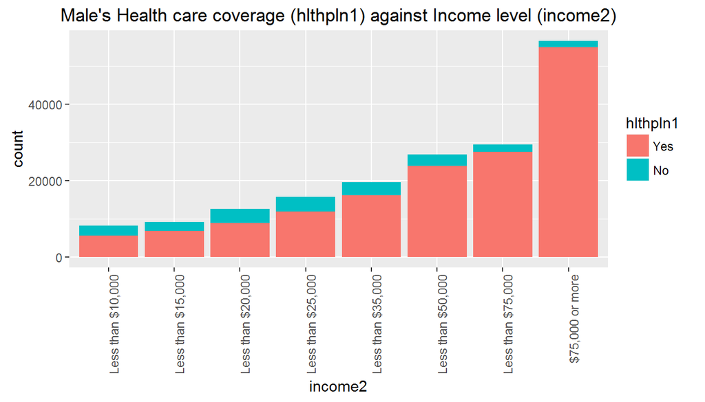

```r
ggplot(data = q1_male_brfss2013, aes(x = income2, fill = hlthpln1)) +
  geom_bar() +
  theme(axis.text.x = element_text(angle = 90, hjust = 1)) +
  labs(title = "Male's Health care coverage (hlthpln1) against Income level (income2)")
```

Summary statistics for Male’s health care coverage (hlthpln1) grouped by income level (income2)

```r
q1_male_result <- q1_male_brfss2013 %>%
  group_by(income2) %>%
  summarise(hlthpln1_rate = sum(hlthpln1 == "Yes") / n()) %>%
  arrange(desc(hlthpln1_rate))
q1_male_result
```

```
## # A tibble: 8 x 2
##             income2 hlthpln1_rate
##              <fctr>         <dbl>
## 1   $75,000 or more     0.9707117
## 2 Less than $75,000     0.9371699
## 3 Less than $50,000     0.8879339
## 4 Less than $35,000     0.8256693
## 5 Less than $25,000     0.7542886
## 6 Less than $15,000     0.7480616
## 7 Less than $20,000     0.7109494
## 8 Less than $10,000     0.6682476
```

Interpretation: There is a positive correlation between income level and male’s health care coverage.

Bar plot for Female’s health care coverage (hlthpln1) against income level (income2)

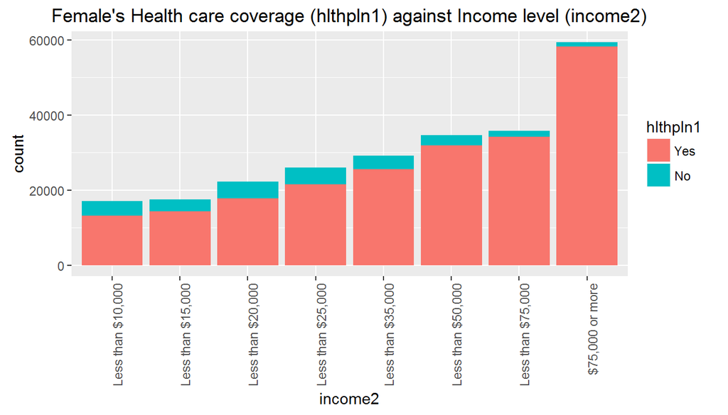

```r
ggplot(data = q1_female_brfss2013, aes(x = income2, fill = hlthpln1)) +
  geom_bar() +
  theme(axis.text.x = element_text(angle = 90, hjust = 1)) +
  labs(title = "Female's Health care coverage (hlthpln1) against Income level (income2)")
```

Summary statistics for Female’s health care coverage (hlthpln1) grouped by income level (income2)

```r
q1_female_result <- q1_female_brfss2013 %>%
  group_by(income2) %>%
  summarise(hlthpln1_rate = sum(hlthpln1 == "Yes") / n()) %>%
  arrange(desc(hlthpln1_rate))
q1_female_result
```

```
## # A tibble: 8 x 2
##             income2 hlthpln1_rate
##              <fctr>         <dbl>
## 1   $75,000 or more     0.9811702
## 2 Less than $75,000     0.9561416
## 3 Less than $50,000     0.9184422
## 4 Less than $35,000     0.8762590
## 5 Less than $25,000     0.8286662
## 6 Less than $15,000     0.8146839
## 7 Less than $20,000     0.8001618
## 8 Less than $10,000     0.7759086
```

Interpretation: There is a positive correlation between income level and female’s health care coverage.

**Research quesion 2: What are the flu shot in the past 12 months ratio across different income levels for men and women?**

The dataset is divided by sex into 2 sets, and entry with not applicable (NA) cell for income and flu shot column are filtered.

```r
q2_male_brfss2013 <- brfss2013 %>%
  filter(sex == "Male", !(is.na(income2)),!(is.na(flushot6)))
q2_female_brfss2013 <- brfss2013 %>%
  filter(sex == "Female", !(is.na(income2)),!(is.na(flushot6)))
```

Bar plot for Male’s flu shot in past 12 months (flushot6) against income level (income2)

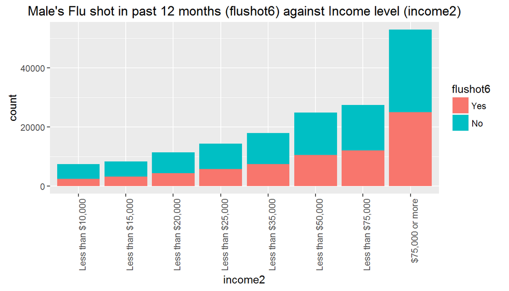

```r
ggplot(data = q2_male_brfss2013, aes(x = income2, fill = flushot6)) +
  geom_bar() +
  theme(axis.text.x = element_text(angle = 90, hjust = 1)) +
  labs(title = "Male's Flu shot in past 12 months (flushot6) against Income level (income2)")
```

Summary statistics for Male’s flu shot (flushot6) grouped by income level (income2)

```r
q2_male_result <- q2_male_brfss2013 %>%
  group_by(income2) %>%
  summarise(flushot6_rate = sum(flushot6 == "Yes") / n()) %>%
  arrange(desc(flushot6_rate))
q2_male_result
```

```
## # A tibble: 8 x 2
##             income2 flushot6_rate
##              <fctr>         <dbl>
## 1   $75,000 or more     0.4714448
## 2 Less than $75,000     0.4361683
## 3 Less than $50,000     0.4217433
## 4 Less than $35,000     0.4137471
## 5 Less than $25,000     0.3980854
## 6 Less than $15,000     0.3833494
## 7 Less than $20,000     0.3786648
## 8 Less than $10,000     0.3156406
```

Interpretation: There is a positive correlation between income level and male’s flu shot in past 12 months.

Bar plot for Female’s flu shot in past 12 months (flushot6) against income level (income2)

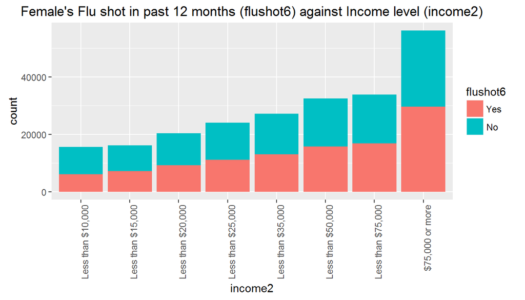

```r
ggplot(data = q2_female_brfss2013, aes(x = income2, fill = flushot6)) +
  geom_bar() +
  theme(axis.text.x = element_text(angle = 90, hjust = 1)) +
  labs(title = "Female's Flu shot in past 12 months (flushot6) against Income level (income2)")
```

Summary statistics for Female’s flu shot (flushot6) grouped by income level (income2)

```r
q2_female_result <- q2_female_brfss2013 %>%
  group_by(income2) %>%
  summarise(flushot6_rate = sum(flushot6 == "Yes") / n()) %>%
  arrange(desc(flushot6_rate))
q2_female_result
```

```
## # A tibble: 8 x 2
##             income2 flushot6_rate
##              <fctr>         <dbl>
## 1   $75,000 or more     0.5277832
## 2 Less than $75,000     0.4962455
## 3 Less than $50,000     0.4844885
## 4 Less than $35,000     0.4788095
## 5 Less than $25,000     0.4629985
## 6 Less than $20,000     0.4479769
## 7 Less than $15,000     0.4452021
## 8 Less than $10,000     0.3876621
```

Interpretation: There is a positive correlation between income level and female’s flu shot in past 12 months.

**Research quesion 3: What is the percentage distribution of Body Mass Index (BMI) classes, i.e. “Underweight”,“Normal”, “Overweight”, and “Obesity”, for men and women.**

BMI quantifies the amount of tissue mass (muscle, fat, and bone) in an individual, and then categorize that person as underweight, normal weight, overweight, or obese based on that value [2]. BMI is given by the following equation for weight in pounds and height in inches:

$$BMI = 703\times\frac{weight}{height^{2}}$$

The original dataset is filtered for weights reported in pounds (i.e. 50 $\leq$ weight2 $\leq$ 999) and heights reported in ft/in (i.e. 200 $\leq$ height3 $\leq$ 711) [3]. The height column is further converted into values purely in inches. Then BMI values according to the above formula are computed.

```r
q3_brfss2013 <- brfss2013 %>%
  filter(!(is.na(sex)),!(is.na(weight2)),!(is.na(height3))) %>%
  filter(weight2 != "", height3 != "") %>%
  mutate(weightNumeric = as.numeric(weight2) ) %>%
  filter(weightNumeric >=50, weightNumeric <=999) %>%
  filter(height3 >=200, height3 <=711) %>%
  mutate(heightInch =  floor(height3/100)*12 + (height3-floor(height3/100)*100)) %>%
  mutate(bmi = 703 * weightNumeric / (heightInch*heightInch))
```

Histogram for Male’s BMI values

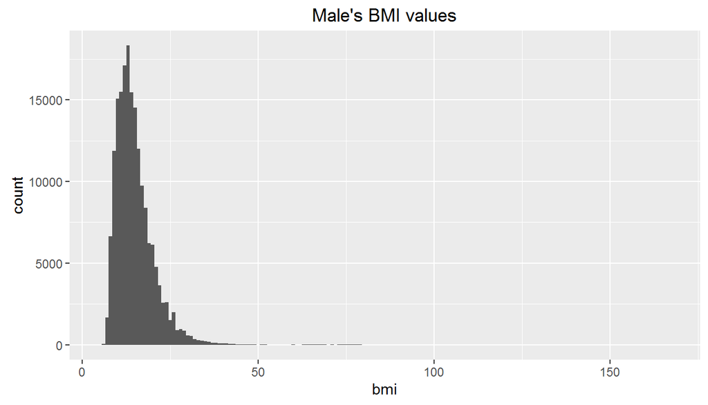

```r
q3_male_brfss2013 <- q3_brfss2013 %>%
  filter(sex == "Male")
ggplot(data = q3_male_brfss2013, aes(x = bmi)) +
  geom_histogram(binwidth = 1) +
  labs(title = "Male's BMI values")
```

Interpretation: The distribution of Male’s BMI values is skewed to the right.

Histogram for Female’s BMI values

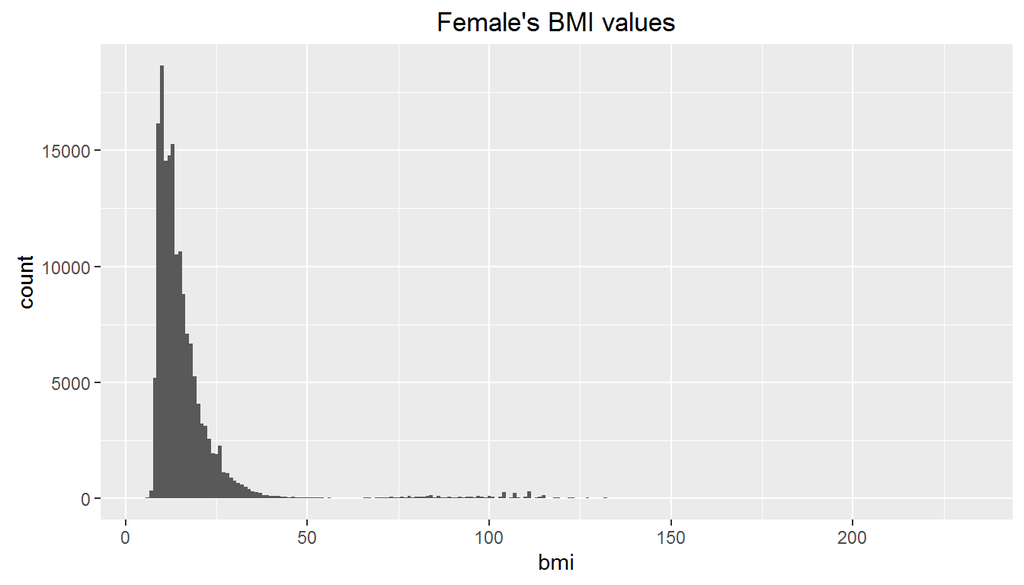

```r
q3_female_brfss2013 <- q3_brfss2013 %>%
  filter(sex == "Female")
ggplot(data = q3_female_brfss2013, aes(x = bmi)) +
  geom_histogram(binwidth = 1)+
  labs(title = "Female's BMI values")
```

Interpretation: The distribution of Female’s BMI values is also skewed to the right.

Box plot for BMI values according to sex

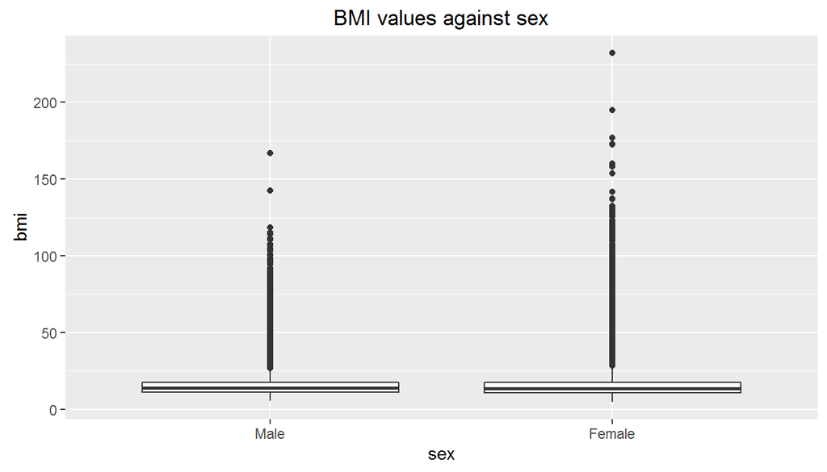

```r
ggplot(data = q3_brfss2013, aes(x = sex, y = bmi)) +
  geom_boxplot()+
  labs(title = "BMI values against sex")
```

Summary statistics BMI values according to sex

```r
q3_result <- q3_brfss2013 %>%
  group_by(sex) %>%
  summarise(meanBMI = mean(bmi), medianBMI = median(bmi),maxBMI = max(bmi), n = n())
q3_result
```

```
## # A tibble: 2 x 5
##      sex  meanBMI medianBMI   maxBMI      n
##   <fctr>    <dbl>     <dbl>    <dbl>  <int>
## 1   Male 14.98323  13.81041 166.9015 182162
## 2 Female 16.26364  13.37889 232.1636 163584
```

Interpretation: Since the distribution of BMI for both male and female are not symmetric, a good measure of center is the median. The median for male BMI is 13.81041 and the median for female BMI is 13.37889.

Classification based on BMI values into BMI classes (i.e. Underweight, Normal, Overweight and Obesity) [2].

```r
q3_class_brfss2013 <- q3_brfss2013 %>%
  mutate(bmi_class =  ifelse(bmi<18.5,"Underweight",ifelse(bmi<25,"Normal",ifelse(bmi<30,"Overweight","Obesity"))))
```

Bar plot for BMI classes according to sex

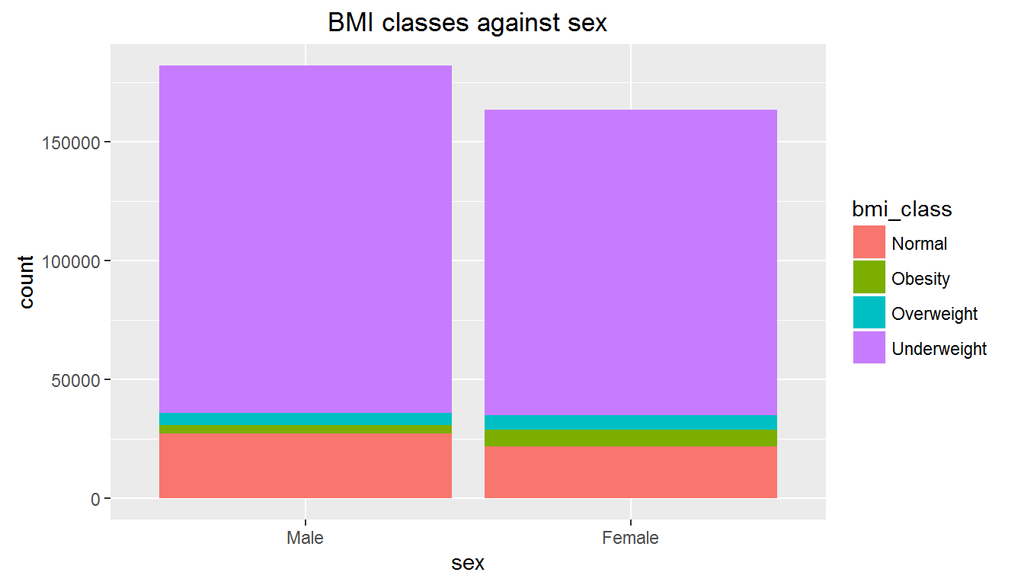

```r
ggplot(data = q3_class_brfss2013, aes(x = sex, fill = bmi_class)) +
  geom_bar() +
  labs(title = "BMI classes against sex")
```

Summary statistics BMI classes according to sex

```r
q3_result2 <- q3_class_brfss2013 %>%
  group_by(sex) %>%
  summarise(percentUnderWeight = sum(bmi_class == "Underweight") / n(), percentNormal = sum(bmi_class == "Normal") / n(),percentOverWeight = sum(bmi_class == "Overweight") / n(), percentObese = sum(bmi_class == "Obesity") / n())
q3_result2
```

```
## # A tibble: 2 x 5
##      sex percentUnderWeight percentNormal percentOverWeight percentObese
##   <fctr>              <dbl>         <dbl>             <dbl>        <dbl>
## 1   Male          0.8030599     0.1498886        0.02864483   0.01840669
## 2 Female          0.7868801     0.1320484        0.03780321   0.04326829
```

Interpretation: Majority of the sample population, 80.3% and 78.7% for men and women respectively, are underweight according to BMI standard.

## References

[1] The BRFSS Data User Guide 2013. Retrieved May 28, 2016. [link](http://www.cdc.gov/brfss/data_documentation/pdf/userguidejune2013.pdf)

[2] Wikipedia - Body mass index. Retrieved May 28, 2016. [link](https://en.wikipedia.org/wiki/Body_mass_index)

[3] BRFSS Cookbook 2013. Retrieved May 28, 2016. link